# Proyecto Final

Pedro Ramírez Garaiz

2026-06-29

Antes de empezar cargamos los paquetes que vamos a usar:

```r
library(dplyr)
library(ggplot2)
library(GGally)
library(tidyr)
```

## Datos

Usaremos las base de datos ‘vehiclethefts_tbl_df’ disponible en el paquete ‘crimedatasets’, que contiene información temporal y geográfica sobre robos vehiculares en la ciudad de Nueva York entre 2014 y 2017.

Para obterner los datos descargamos y cargamos:

```r
install.packages("crimedatasets")
```

```r
library(crimedatasets)
```

### Observaciones iniciales

Para una mirada rápida a la tabla de datos:

```r
head(vehiclethefts_tbl_df)
```

```
## # A tibble: 6 × 9
##        uid date_single      date_start date_end longitude latitude location_type
##      <int> <chr>            <chr>      <chr>        <dbl>    <dbl> <chr>
## 1 12386084 2014-01-01 01:15 2013-12-3… 2014-01…     -73.9     40.7 street
## 2 12386093 2014-01-01 01:25 2014-01-0… 2014-01…     -73.9     40.8 street
## 3 12386163 2014-01-01 02:00 2013-12-3… 2014-01…     -74.0     40.7 street
## 4 12386230 2014-01-01 02:30 2014-01-0… <NA>         -73.9     40.9 street
## 5 12386273 2014-01-01 02:50 2014-01-0… <NA>         -73.9     40.8 street
## 6 12386427 2014-01-01 03:51 2014-01-0… 2014-01…     -73.7     40.6 street
## # ℹ 2 more variables: location_category <chr>, census_block <chr>
```

Vemos el tamaño de la base de datos

```r
dim(vehiclethefts_tbl_df)
```

```
## [1] 35746     9
```

Tenemos observaciones de 9 variables para 35746 casos de robo vehicular, estas variables son:

```r
names(vehiclethefts_tbl_df)
```

```
## [1] "uid"               "date_single"       "date_start"
## [4] "date_end"          "longitude"         "latitude"
## [7] "location_type"     "location_category" "census_block"
```

“uid” es el número de identificación de cada incidente.

“date_start” y “date_end” corresponden al intervalo de tiempo en que el robo pudo ocurrir, “date_single” es el punto medio.

“longitude” y “latitude” dan las coordenadas del lugar del robo.

“location_type” describe el lugar del robo (calle, escuela, gasolinera, etc)

```r
unique(vehiclethefts_tbl_df$location_type)
```

```
##  [1] "street"               "vehicle parking"      "other retail"
##  [4] "residence"            "office"               "commercial vehicle"
##  [7] "other transportation" "other"                "other open space"
## [10] "storage"              "bus"                  "convenience store"
## [13] "gas station"          "religious"            NA
## [16] "supermarket"          "finance"              "bar/club"
## [19] "government"           "healthcare"           "restaurant"
## [22] "construction"         "factory/warehouse"    "hotel"
## [25] "airport"              "green space"          "abandoned"
## [28] "school"
```

“location_category” asigna una categoría al lugar del robo (comercial, gubernamental, residencial, etc)

```r
unique(vehiclethefts_tbl_df$location_category)
```

```
##  [1] "street"         "open space"     "retail"         "residence"
##  [5] "commercial"     "vehicle"        "transportation" "other"
##  [9] NA               "leisure"        "government"     "healthcare"
## [13] "hotel"          "education"
```

## Datos faltantes

Para saber si existen hoyos en los datos

```r
colSums(is.na(vehiclethefts_tbl_df))
```

```
##               uid       date_single        date_start          date_end
##                 0                 0                 0              2852
##         longitude          latitude     location_type location_category
##                 0                 0                 7                 7
##      census_block
##                 0
```

Vemos que existen 2852 incidentes que no especifican una última fecha y hora en que podrían haber ocurrido, mientras que 7 no tienen información cualitativa sobre la ubicación. Filtraremos estos datos cuando sea relevante.

# I. ¿Que clase lugares son los más peligrosos?

Preparamos los, seleccionando las variables relevantes y filtrando los casos que no contienen esta información

```r
info_loc_qual <- vehiclethefts_tbl_df %>%
  select(location_type, location_category) %>%
  filter(!is.na(location_type)) %>%
  filter(!is.na(location_category))
```

Realizamos el conteo de incidentes por categoría y tipo de lugar

```r
#Por categoría
robos_loc_cat <- info_loc_qual %>%
  group_by(location_category) %>%
  summarise(thefts = n()) %>%
  arrange(desc(thefts))

#Por tipo
robos_loc_typ <- info_loc_qual %>%
  group_by(location_type) %>%
  summarise(thefts = n()) %>%
  arrange(desc(thefts))
```

Graficamos:

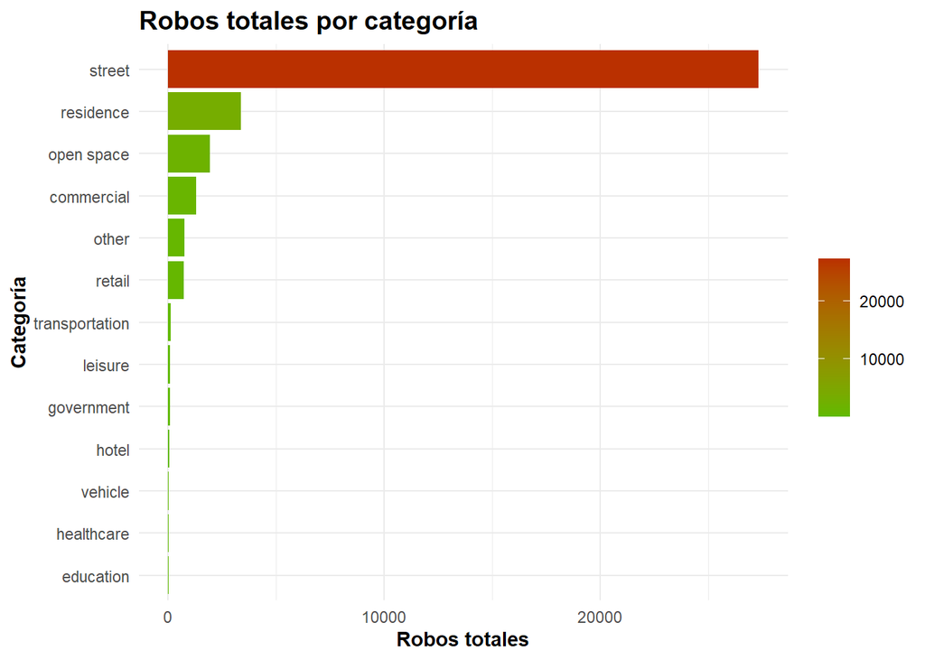

```r
robos_loc_cat %>%

  mutate(location_category = reorder(location_category, thefts)) %>%

  ggplot( aes(x = location_category, y = thefts, fill = thefts ) ) +

  labs(title = "Robos totales por categoría", x = "Categoría", y = "Robos totales", fill = "" ) +

  geom_col() + coord_flip() +

  scale_fill_gradient(low = "#60BA00", high = "#BA3000" ) + theme_custom
```

Es evidente que la calle es mucho más peligrosa que cualquier otro lugar. Podemos filtrar estos casos para comparar el resto de categorías con más detalle

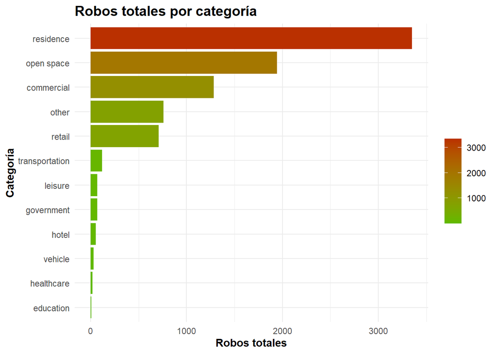

```r
robos_loc_cat %>%

  #Añadimos una linea al inicio para filtrar la categoría "street"
  filter(location_category != "street") %>%

  mutate(location_category = reorder(location_category, thefts)) %>%

  ggplot( aes(x = location_category, y = thefts, fill = thefts ) ) +

  labs(title = "Robos totales por categoría", x = "Categoría", y = "Robos totales", fill = "" ) +

  geom_col() + coord_flip() +

  scale_fill_gradient(low = "#60BA00", high = "#BA3000" ) + theme_custom
```